# Group_06

Author

Analysis of IMDB data set

# 1 Introduction

The study aims to investigate the relationship between various film attributes and IMDB ratings, drawing data from the IMDB film database allocated. The data set comprises of the factors such as film ID, release year, duration, budget, votes, genre, and IMDB rating. The research question focuses on examining the factors that impact IMDB ratings, particularly whether specific film properties contribute to ratings greater than seven. A Generalized Linear Model (GLM) analysis is conducted to derive the relationships between these properties and IMDB ratings.

# 2 Data Wrangling Methods

Before we begin the analysis of our data, let’s transform the data using various tools. The process below describes the detailed data wrangling techniques that are used to get the desired data set. After having a glimpse of the data set, the ‘genre’ column is converted to a type factor type.

A check for missing values is conducted and it is found that 103 observations are missing from the column ‘length’. Missing values are imputed with the median since median is a robust measure, less impacted by outliers as much as mean. The function *median( )* reveals the median to be 90 minutes. However, it is observed in Table 1 that the median lengths vary across the different genres. With this information, the missing lengths of films are replaced by median length of the respective genre.

Table 1: Median length by genre

| genre | median_length |
| --- | --- |
| Action | 90.0 |
| Animation | 7.0 |
| Comedy | 91.0 |
| Documentary | 73.0 |
| Drama | 96.0 |
| Romance | 92.5 |
| Short | 13.5 |

As per the research question, a new column ‘high_rating’ containing binary variables coressponding to ‘rating’ values is created. This column takes a value of 1 for IMDB ratings greater than or equal to seven and 0 for IMDB ratings less than seven. Additionally, another categorical variable ‘rate’ conveying the same is also added.

# 3 Exploratory Data Analysis

## 3.1 view the data

Check on the size of a data set

```
[1] 1937    9
```

Sample size is 1937. And it have 9 variables,7 of which are in the original data.

Let’s have a look at the first five rows of the data frame.

Table 2: Glimpse of the first five rows in the IMDB data set

| film_id | year | length | budget | votes | genre | rating | high_rating | rate |
| --- | --- | --- | --- | --- | --- | --- | --- | --- |
| 31804 | 2002 | 18 | 9.6 | 15 | Drama | 8.0 | 1 | Rating greater than 7 |
| 25453 | 2000 | 98 | 13.8 | 23 | Action | 3.3 | 0 | Rating less than 7 |
| 5479 | 1989 | 81 | 11.5 | 57 | Documentary | 7.9 | 1 | Rating greater than 7 |
| 44235 | 1995 | 100 | 7.5 | 32 | Action | 3.4 | 0 | Rating less than 7 |
| 14580 | 2003 | 80 | 10.8 | 30 | Action | 2.6 | 0 | Rating less than 7 |

The variables in Table 2

- **film.id** : The unique identifier for the film
- **year** : Year of release of the film in cinemas
- **length** : Duration (in minutes)
- **budget** : Budget for the films production (in $1000000s)
- **votes** : Number of positive votes received by viewers
- **genre** : Genre of the film
- **rating** : IMDB rating from 0 to10
- **high_rating** : 1 for IMDB ratings greater than or equal to seven and 0 for IMDB ratings less than 7
- **rate** : ‘Rating greater than 7’ got high_rating = 1 and ‘Rating less than 7’ for high_rating = 0

## 3.2 Summary Statistics

Since variables year, length,budget,votes,rating are continuous, we need get their summary contains mean,median,standard deviation,minimum maximum.

Table 3: Summary statistics on the IMDB data by variables

| Variables | Mean | Median | Std. Dev | Minimum | Maximum | Interquartile Range | Sample Size |
| --- | --- | --- | --- | --- | --- | --- | --- |
| year | 1,976.21 | 1,982.00 | 23.44 | 1,896.00 | 2,005.00 | 39.00 | 1,937.00 |
| length | 82.88 | 90.00 | 35.62 | 1.00 | 316.00 | 24.00 | 1,937.00 |
| budget | 12.03 | 12.00 | 2.92 | 3.20 | 21.20 | 3.90 | 1,937.00 |
| votes | 590.47 | 31.00 | 3,894.33 | 5.00 | 103,854.00 | 104.00 | 1,937.00 |

The Table 3 shows that the summary for the columns year, length, budget and votes.

• The number of films in sample is 1937.

• For the variable year, the years of the films ranged from 1896 to 2005.

• For variable budget, the budget of films is from 3.2 ($1000000s) to 21.2 ($1000000s).The median budget of a movie is 12($1000000s).

• For variable votes, the votes of films is from 5 to 103,854.The range of variation is very large, and the IQR is relatively large. The data is not stable.

## 3.3 Correlation

Check correlations (as scatterplots), distribution and print correlation coefficient.

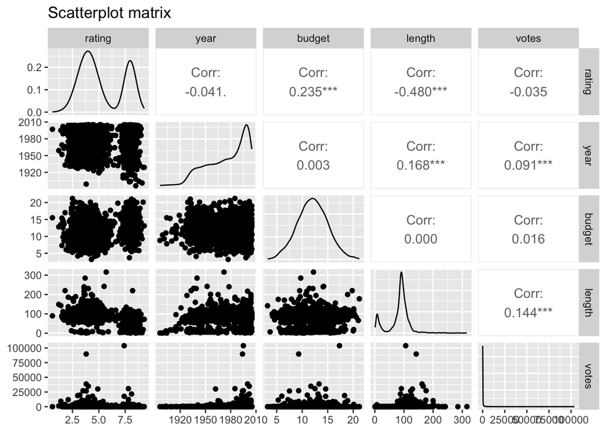

Figure 1: Scatterplot matrix between rating and explanatory variables

Figure 1 shows rating and budget show a significant linear positive correlation. And rating is significant linear negative correlation with length. Between rating and year,votes have weak correlation.

## 3.4 Visualization

### 3.4.1 Histograms for continuous variable(rating,year,budget,length,votes)

Histograms to understand the data structures of different variables

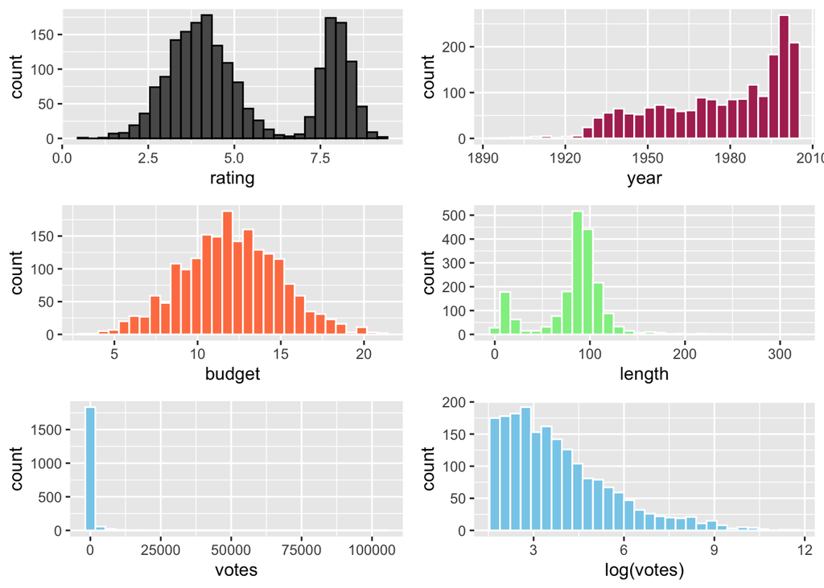

Figure 2: Histograms of statistical distribution for varibles

The variable votes has a large data difference and deviation, so we can log transformation for votes.

### 3.4.2 Visualise the distributions of categorical variable genre

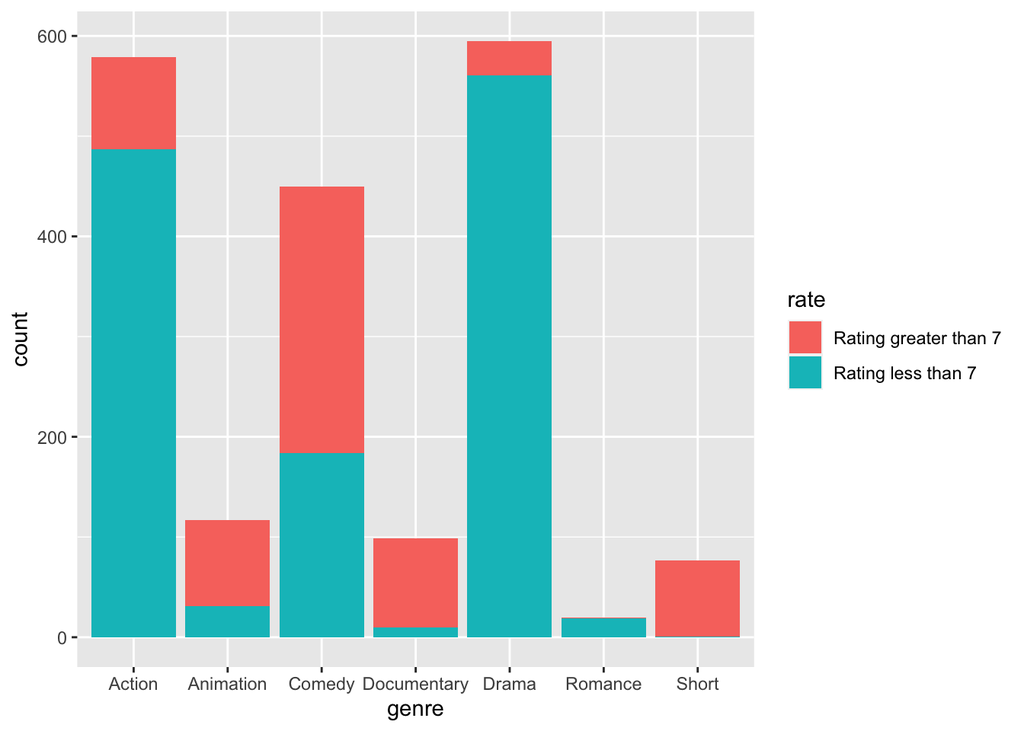

Figure 3: Stacked barplot of statistical distribution for ratings by genre

## 3.5 The relationship between rating and explanatory variables

Scatterplots to understand the relationship between rating and four variables(year,length,budget,log_votes)

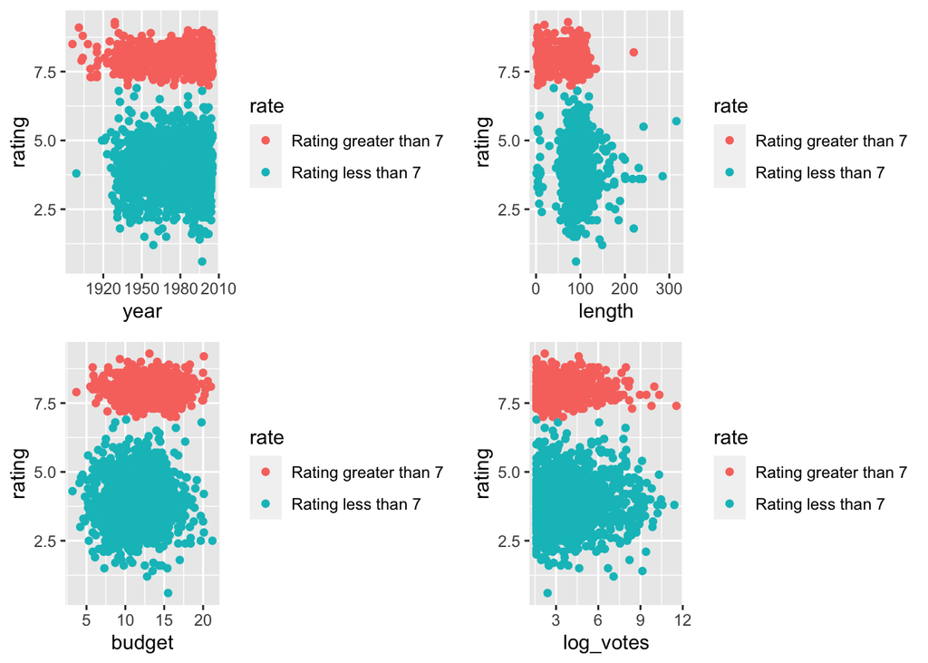

Figure 4: Scatterplots between rating and four explanatory variables.

### 3.5.1 Boxplot to understand the relationship between rating and Categorical variable genre

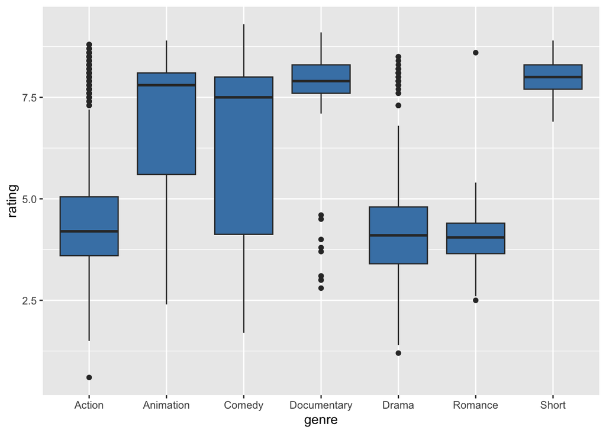

Figure 5: Boxplot of ratings by genre.

## 3.6 The relationship response and explanatory variable

### 3.6.1 variable1:Length

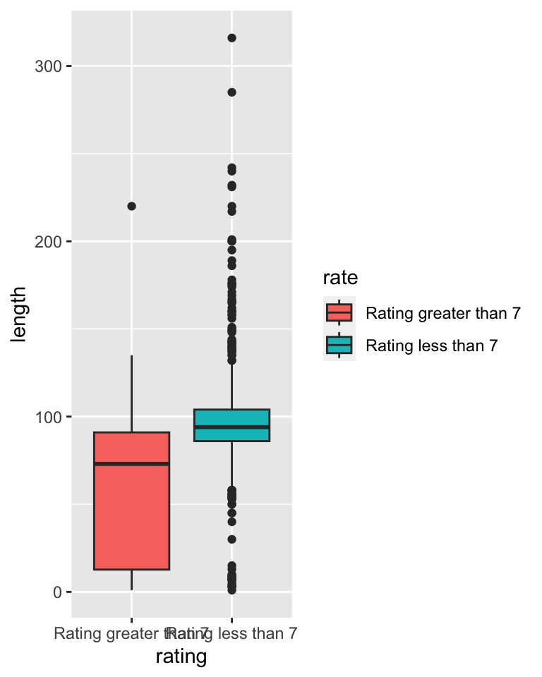

Figure 6: Boxplot of length by rating

Figure 6 shows that the median film length of high rating films is less than that of low rating films. It can Interquartile Range of low rating is smaller than that of high rating, which shows that the data about low rating is more concentrated.

Table 4: Summary statistics on length by rating

| rate | Mean | Median | Std. Dev | Minimum | Maximum | Interquartile Range | Sample Size |
| --- | --- | --- | --- | --- | --- | --- | --- |
| Rating greater than 7 | 57.05 | 73.00 | 39.49 | 1.00 | 220.00 | 78.25 | 644.00 |
| Rating less than 7 | 95.74 | 94.00 | 25.03 | 1.00 | 316.00 | 18.00 | 1,293.00 |

### 3.6.2 variable2:Budget

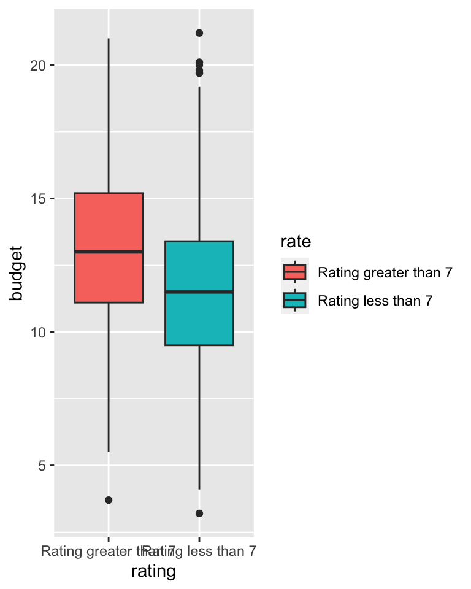

Figure 7: Boxplot of budget by rating

Figure 7 shows that the median budget film of high rating films is higher than that of low rating films.

Table 5: Summary statistics on budget by rating

| rate | Mean | Median | Std. Dev | Minimum | Maximum | Interquartile Range | Sample Size |
| --- | --- | --- | --- | --- | --- | --- | --- |
| Rating greater than 7 | 13.09 | 13.00 | 2.84 | 3.70 | 21.00 | 4.10 | 644.00 |
| Rating less than 7 | 11.51 | 11.50 | 2.82 | 3.20 | 21.20 | 3.90 | 1,293.00 |

### 3.6.3 variable3:votes(ln)

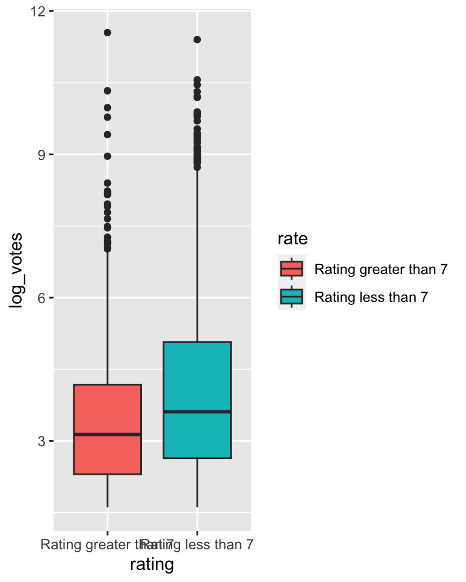

Figure 8: Boxplot of log_votes by rating.

Figure 8 shows that the median log_votes film of high rating films is lower than that of low rating films.

Table 6: Summary statistics of votes(log) by rating.

| rate | Mean | Median | Std. Dev | Minimum | Maximum | Interquartile Range | Sample Size |
| --- | --- | --- | --- | --- | --- | --- | --- |
| Rating greater than 7 | 3.47 | 3.14 | 1.58 | 1.61 | 11.55 | 1.88 | 644.00 |
| Rating less than 7 | 4.03 | 3.61 | 1.86 | 1.61 | 11.40 | 2.43 | 1,293.00 |

The Table 6 hows that the mean log_votes film with high rating(3.47) is lower than that with low rating(4.03). In general, there were fewer log_votes for films with high ratings.

### 3.6.4 variable4:genre

The ratio of ratings above 7 to ratings below 7 and sample sizes for each type

```
       genre Rating greater than 7 Rating less than 7 genre_sum_count
      Action           15.9%  (92)        84.1% (487)             579
   Animation           73.5%  (86)        26.5%  (31)             117
      Comedy           59.1% (266)        40.9% (184)             450
 Documentary           89.9%  (89)        10.1%  (10)              99
       Drama            5.7%  (34)        94.3% (561)             595
     Romance            5.0%   (1)        95.0%  (19)              20
       Short           98.7%  (76)         1.3%   (1)              77
```

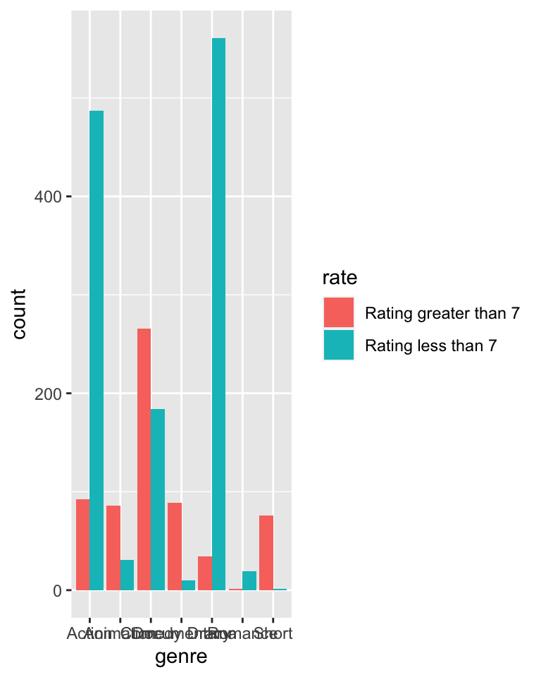

Figure 9: Dodged barplot of genre by reating.